# Project 3: Bioinformatics of Gene Expression

### 2.3.6. Compare the two confusion matrices.

Lastly, let’s compare the results of what we just ran (stored in `confMatCV`) with what we the OOB performance from Demo_3 (stored in `confMat`).

Table 2. Comparing Accuracy - Random Forest

| Metric | Confusion Matrix 1 | Confusion Matrix 2 |
| --- | --- | --- |
| Accuracy | 0.4285714 | 0.4285714 |
| Kappa | -0.1428571 | -0.1428571 |
| AccuracyLower | 0.1766111 | 0.1766111 |
| AccuracyUpper | 0.7113906 | 0.7113906 |
| AccuracyNull | 0.5000000 | 0.5000000 |
| AccuracyPValue | 0.7880249 | 0.7880249 |
| McnemarPValue | 1.0000000 | 1.0000000 |

#### **Question 8**: Let’s take a moment to unpack what we are looking at here. What do each of these metrics measure? **Hint**: Make sure to look at the documentation for the `confusionMatrix()` function from `caret`.

Sources:

Ariza-Lopez, Francisco Javier, et al. “Package ‘ConfMatrix.’” CRAN R, 30 May 2026, cran.r-project.org/web/packages/ConfMatrix/ConfMatrix.pdf.

“confusionMatrix: Create a Confusion Matrix.” Rdocumentation, www.rdocumentation.org/packages/caret/versions/7.0-1/topics/confusionMatrix. Accessed 27 June 2026.

“ConfusionTableR.” CRAN R, cran.r-project.org/web/packages/ConfusionTableR/vignettes/ConfusionTableR.html. Accessed 27 June 2026.

I used the caret::confusionMatrix document through the Help Page in R.

> **Accuracy Null**: The AccuracyNull metric represents the “no information rate”, which is the largest class percentage in the data. Therefore, the AccuracyNull provides a baseline value for model performance. Both Confusion Matrix 1 (OOB model) and Confusion Matrix 2 (10-Fold CV model) have an AccuracyNull of 0.50 (50%).

#### **Question 9**: What was the impact, if any, of the pre-processing we performed here? What evidence do you have? Lastly, what was the biggest change, other than tuning, that we made as compared to the OOB RF?

> One of the pre-processing steps was using the filterCutoff to filter out genes. This was a form of feature reduction, as the filterCutoff value of 5 that we used reduced the number of predictors from over 12,000 to 7,676. This helped reduce noise and overfitting in the dataset.

#### **Question 10**: What are your conclusions, at this stage, about the performance of the 10-fold CV, tuning, and applying the filtering cutoff relative to the OOB performance from Demo_3?

> The performance of the 10-fold CV, tuning, and the application of the filtering cutoff allowed us to get a better understanding of model stability and accuracy. In Demo_3, the OOB performance on the training data had very high performance, including an accuracy and kappa of 1. This highlights a potential overfitting issue with the data, as results this strong are unlikely. It was also noted that the McnemarPValue was NaN.

> Overall, these results are showing that we continue to deal with the big p little n problem, which can impact the results of cross-validation, as we have a large number of predictors and a small number of observations. We saw this in the accuracy results, which had a lot of variability.

## 2.4 Further Tuning: Searching

Hyperparameter tuning is akin to looking for a needle in a haystack. Each model we fit will have its own set of unique hyperparameters, and thus they are not something that you can “guess” or “estimate”. Thus, the only approach to narrow our search is to evaluate a wide range of values for each hyperparameter (kind of like setting fire to the haystack, computationally speaking). We can allow packages like `caret` to automatically search for us (as we just did), but if the goal is to generate the most exhaustive search of hyperparameters - and in a way that is agnostic to human error - we need to do a **search**. Searches come in several flavors, but we will be executing a **grid** search vs. a **random** search for our study because both are quite simple to execute with the packages we already have.

### 2.4.1 Grid Search

As the name suggests, grid searches take a matrix of values and will iteratively and linearly search through the grid until all combinations have been tested. This is also sometimes referred to as a ‘Cartesian grid’ search.

##### How many searches to do?

You will always be limited by time & computational resources. As much as I would like this to be exhaustive, for our purposes we will be keeping this smaller and more manageable since we are not running it on a computing cluster or in parallel.

##### A Note about Randomness

You may have already noticed that you get different results from your teammates or even if you run it yourself over and over. Why? By default, `caret` is setting a random seed for each split, and so you could have a different set of seeds than someone else (or even versus when you run it again). Wait, that’s not terribly helpful, is it?

It is and it isn’t. You might imagine times when you just want to be able to run a model, check the fit, and move on. Other times, like this time, we need something highly reproducible. `caret` will allow us to set our seeds so that we can force it to be more reproducible. Once we have some seeds to add, we update the `kFoldctrl` object.

**NOTE**: When you strike out on your own, you may get a ‘bad seeds’ error. This is often because you need to increase the size of your sample space.

#### 2.4.1.1. Set the search grid.

```r
searchGrid <- expand.grid(
  mtry = floor(ncol(train) * c(.05, .15, .25, .35, .45)),
  splitrule = c("gini", "extratrees"),
  min.node.size = c(1, 3, 5, 10)
)
```

#### **Question 11**: How many different combinations are we going to search with this grid?

> In the above code chunk, there are 5 mtry values: .05, .15, .25, .35, and .45. There are 2 splitrule values: gini and extratrees. Lastly, there are 4 min.node.size values: 1, 3, 5, and 10.

```r
# Calculate the number of different combinations we will search with this grid
5 * 2 * 4
```

```
## [1] 40
```

> We will search 40 different combinations with this grid.

#### 2.4.1.2. Run the RF, this time adding in the search grid.

Be patient. This may take a few minutes to run.

```r
rfTuned <- train(Treatment ~.,
               data = train,
               method = "ranger",
               trControl = kFoldCtrl,
               tuneGrid = searchGrid # Add in the search grid
)
```

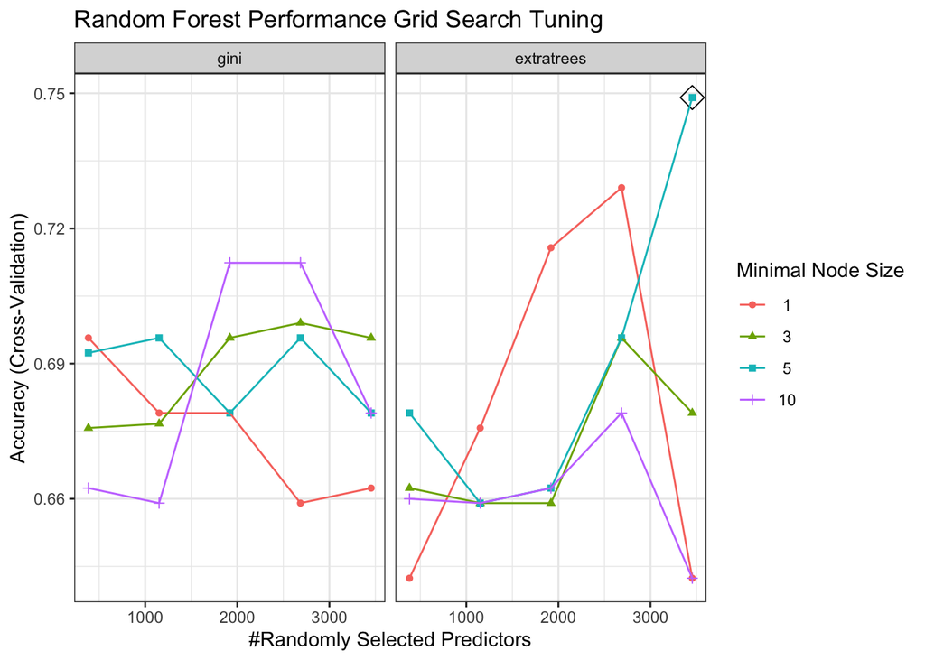

Figure 2. Visualize the Grid Search Performance

#### 2.4.1.3. Take a look at the hyperparameters of the best model.

```r
rfTuned$bestTune %>%
kable(
    format = "html",
    caption = "Table 3. Results of the Grid Search on Random Forest") %>%
    kable_styling(bootstrap_options = c("hover", full_width = F))
```

Table 3. Results of the Grid Search on Random Forest

|  | mtry | splitrule | min.node.size |
| --- | --- | --- | --- |
| 39 | 3454 | extratrees | 5 |

#### 2.4.1.4. Fit the best model’s hyperparameters to the test data.

```r
rfTuned <- train(Treatment ~.,
               data = train,
               method = "ranger",
               trControl = kFoldCtrl,
               tuneGrid = rfTuned$bestTune)   ## Use the best model
```

#### 2.4.1.5. Make the new predictions to assess accuracy.

```r
pred.test.rf <- predict(rfTuned, test, type = "raw")  ## type is now 'raw'
# Store the confusion matrix
confMatTuned <- confusionMatrix(pred.test.rf, test$Treatment)
```

#### 2.4.1.6. Compare the three confusion matrices.

```r
compareConfusion(confusionList = list(confMat, confMatCV, confMatTuned)) %>%
    kable(
    format = "html",
    caption = "Table 4. Comparing Accuracy - Random Forest") %>%
    kable_styling(bootstrap_options = c("hover", full_width = F))
```

Table 4. Comparing Accuracy - Random Forest

| Metric | Confusion Matrix 1 | Confusion Matrix 2 | Confusion Matrix 3 |
| --- | --- | --- | --- |
| Accuracy | 0.4285714 | 0.4285714 | 0.4285714 |
| Kappa | -0.1428571 | -0.1428571 | -0.1428571 |
| AccuracyLower | 0.1766111 | 0.1766111 | 0.1766111 |
| AccuracyUpper | 0.7113906 | 0.7113906 | 0.7113906 |
| AccuracyNull | 0.5000000 | 0.5000000 | 0.5000000 |
| AccuracyPValue | 0.7880249 | 0.7880249 | 0.7880249 |
| McnemarPValue | 1.0000000 | 1.0000000 | 1.0000000 |

#### **Question 13**: What impact did hyperparameter tuning with the grid search have on model performance compared to both the OOB and 10-fold CV with auto-tuning?

**Note on methodology**: As I mentioned above, there is no parameter for the number of trees that we could tune in the search grid. Why not? It’s because we used the `train()` function from the `caret` package. `train()` is what is called a **wrapper function**, which means that we may be somewhat stuck using what’s available to us in the function. But what if we want to tune hyperparameters that are available through that wrapper function? We would need to switch our tactics. We could either write a **custom function or loop** to do it, or we could modify the function in `caret`. Wait, we can do that?! Yep!

#### **Question 14**: Use the `modelLookup` function to help you figure out what hyperparameters are available for the `rf` vs. `ranger` methods for performing random forest algorithm with `caret`. What are the key differences you observce in the hypers you can tune?

```r
# Uncommented to run
 modelLookup("ranger")
```

```
##    model     parameter                         label forReg forClass probModel
## 1 ranger          mtry #Randomly Selected Predictors   TRUE     TRUE      TRUE
## 2 ranger     splitrule                Splitting Rule   TRUE     TRUE      TRUE
## 3 ranger min.node.size             Minimal Node Size   TRUE     TRUE      TRUE
```

```r
 modelLookup("rf")
```

```
##   model parameter                         label forReg forClass probModel
## 1    rf      mtry #Randomly Selected Predictors   TRUE     TRUE      TRUE
```

> The modelLookup function showed that there are different hyperparameters that can be tuned for ranger and rf. The ranger method allows the following parameters to be tuned: mtry (number of randomly selected predictors), splitrule (gini or extratrees), and min.node.size (minimum number of observations in a node). The rf method only allows mtry to be tuned and is very limited.

### 2.4.2 Grid Search Using a Customized `caret` Method

#### 2.4.2.2. Run the customized method.

**NOTE**: This takes about 12 min to run on 16gb of RAM. This is exactly why we are doing caching for this assignment. Otherwise, your report will take forever to re-knit.

```r
## Run the custom method setting the hyperparameters we want to use
customRF <- makeCustomMethod(paramList = c("mtry",
                                           "num.trees",
                                           "min.node.size",
                                           "splitrule"),
                             methodName = "ranger")

## Now expand the search grid
searchGrid <- expand.grid(.mtry = floor(ncol(train) * c(.05, .15, .25)),
                        .num.trees = c(50, 200),
                        .min.node.size = c(1, 5, 10, 20),
                        .splitrule = "gini"
                        )
## Now run the RF with the custom tuned hypers and the new search grid
customTuned <- train(y = train$Treatment, x = train,
                method = customRF,
                metric = "Accuracy",
                tuneGrid = searchGrid,
                trControl = kFoldCtrl)
```

#### **Question 16**: Did you catch that I am setting `.splitrule = gini` explicitly? Why do you think I made this choice?

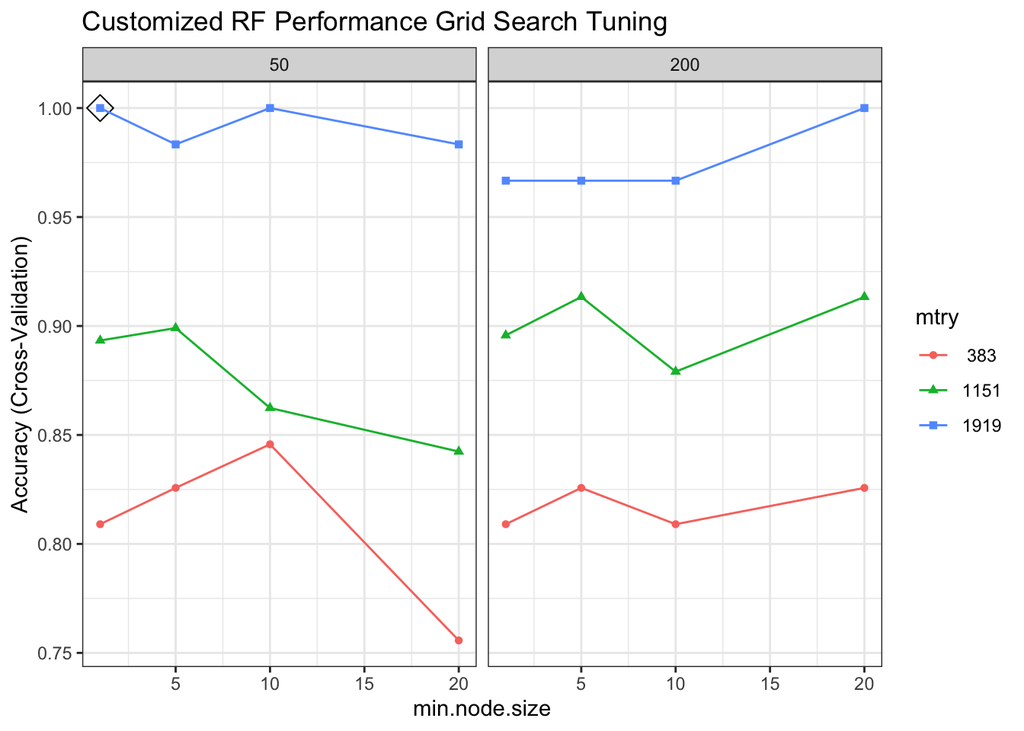

Figure 3. Visualize the Customized Grid Search Performance

#### 2.4.2.3. Take a look at the hyperparameters of the best model.

```r
customTuned$bestTune %>%
kable(
    format = "html",
    caption = "Table 5. Results of the Customized Grid Search on Random Forest") %>%
    kable_styling(bootstrap_options = c("hover", full_width = F))
```

Table 5. Results of the Customized Grid Search on Random Forest

|  | mtry | num.trees | min.node.size | splitrule |
| --- | --- | --- | --- | --- |
| 17 | 1919 | 50 | 1 | gini |

#### 2.4.2.4. Refit the best model’s hyperparameters to the test data set.

```r
newTuned <- train(Treatment ~.,
               data = train,
               method = customRF,
               trControl = kFoldCtrl,
               tuneGrid = customTuned$bestTune)
```

#### 2.4.2.5. Make the new predictions to assess accuracy.

```r
pred.test.rf <- predict(newTuned, test, type = "raw")
# Store the confusion matrix
confMatTuned2 <- confusionMatrix(pred.test.rf, test$Treatment)
```

#### 2.4.2.6. Compare the four confusion matrices.

Table 6. Comparing Accuracy - Random Forest

| Metric | Confusion Matrix 1 | Confusion Matrix 2 | Confusion Matrix 3 | Confusion Matrix 4 |
| --- | --- | --- | --- | --- |
| Accuracy | 0.4285714 | 0.4285714 | 0.4285714 | 0.5000000 |
| Kappa | -0.1428571 | -0.1428571 | -0.1428571 | 0.0000000 |
| AccuracyLower | 0.1766111 | 0.1766111 | 0.1766111 | 0.2303605 |
| AccuracyUpper | 0.7113906 | 0.7113906 | 0.7113906 | 0.7696395 |
| AccuracyNull | 0.5000000 | 0.5000000 | 0.5000000 | 0.5000000 |
| AccuracyPValue | 0.7880249 | 0.7880249 | 0.7880249 | 0.6047363 |
| McnemarPValue | 1.0000000 | 1.0000000 | 1.0000000 | 1.0000000 |

#### **Question 18**: How well did hyperparameter tuning with the number of trees and the new grid search perform? Are we seeing sufficient improvement to continue down this path?

**Hint**: Make sure to check model stability again as well by looking at the performance across folds, even though I didn’t do that for you.

```r
# Check model stability across folds
customTuned$resample
```

```
##    Accuracy Kappa Resample
## 1         1     1   Fold01
## 2         1     1   Fold05
## 3         1     1   Fold10
## 4         1     1   Fold06
## 5         1     1   Fold09
## 6         1     1   Fold03
## 7         1     1   Fold08
## 8         1     1   Fold04
## 9         1     1   Fold02
## 10        1     1   Fold07
```

> The above code chunk checks the model stability again by looking at performance across folds. It provides an interesting result: across all 10 folds, both the accuracy and kappa are 1. This would indicate near-perfect model performance, which is unlikely and is not shown in our current performance metrics. These results come back to the big p little n scenario we have with this data, since there are a large number of predictors and a small number of observations.

### 2.4.3 Random Search

A random search is where we randomly choose hyperparameters and, based on an initial set of random values, iteratively search until we get closer and closer to the best fit. Now, at this point we might also consider performing a random search in addition to the grid search; however, as we can see that we are generally STILL seriously under-performing, let’s table that idea and put our efforts somewhere we will hopefully see a bigger impact: **Nested Cross-Validation**.

## 2.5 Nested Cross-Validation

As we have already discussed in lecture and Demo_3, the norm in machine learning is to have a lot more observations ($n$) than the number of features ($P$). Although it is tempting to think the same thing here, remember that the columns here are not features but rather samples, giving us a $P >> N$ problem.

Whenever $P >> N$ as here, our typical approaches for cross-validation must change. We have several options, but here we will employ a **nested cross-validation** approach. Other options would include a hold out or leave-one-out, although with some caveats.

**You will find that this method is not employed as much as it should be yet in gene expression analysis.** Why? Conceptually, this may be a bit hard to understand - and ML methods are already really different from what is done with the conventional methods like `DESeq2`. Let’s go over what nested CV is to try to unpack this a little.

### 2.5.2 The `nestedcv` package

Although we can also execute this with custom functions or loops, it’s usually going to be far more expedient to leverage a pre-existing package. Here, we will use the `nestedcv` package.

`nestedcv` partitions the dataset into outer and inner folds, with the default being 10-fold outer CV and 10-fold inner CV, also called **10 x 10 folds** CV. The inner-fold cross validation tunes the optimal hyperparameters for whatever model(s) are run. The model is then fitted on the whole inner-fold and tested against the left-out data from the outer-fold. This is repeated across all outer-folds. Then, the test predictions from the outer-folds are compared against the true results for the test outer-folds. The combined results give a measure of accuracy for the whole dataset as you are accustomed, e.g., either RMSE for regression or AUC for classification.

Lastly, a final round of cross-validation is performed on the whole dataset to determine hyperparameters to fit the final model to the whole data, which can be used for prediction with external data (which could be yet another test set you have withheld, for example, as we’ve been doing).

**Whew!**

Shall we try it?!?

### 2.5.3 Running a Nested CV

#### 2.5.3.1. Set a search grid and train the model using the `nestedcv.train()` function.

Note that the setup looks a little reminiscent of our customized `caret` function. That’s because the authors of this package are doing something similar, although they have improved the computational speed. We could do that too - **if** we wanted to write a package. Otherwise, we can just let ours run and take a coffee/tea break. :)

**IMPORTANT!**: We are not able to use $m_{try}$ as large as we are used to because we’re doing inner- and outer-folds. We lowered $m_{try}$ here as a result. If you are doing this on different data and you get an error, that’s something to look into!

**Note**: This took 14 mins on 16gb RAM, depending on what else I was asking my computer to do at the same time.

```r
searchGrid <- expand.grid(.mtry = floor(ncol(train) * c(0.01, 0.05, 0.10)),
                        .min.node.size = c(1, 5, 10),
                        .splitrule = "gini"
                        )
ncv <- nestcv.train(y = train$Treatment, x = train,
                    method = 'ranger',
                    tuneGrid = searchGrid,
                    savePredictions = "final")
```

```
## Fitting final model using CV on whole data
```

```
## Performing 10-fold outer CV, using 1 core
```

```
## Duration: 14.98396 mins
```

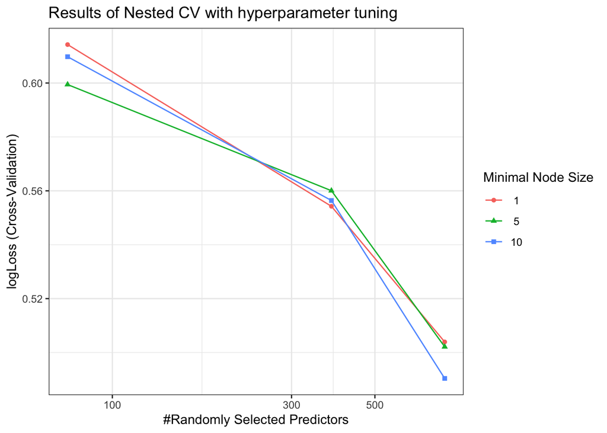

Figure 4. Visualize the Nested CV Performance on RF + Grid Search

#### **Question 19**: Notice that the y-axis is now **log-Loss** and not **accuracy**. You may need to do some digging, but can you figure out why? Citing sources can be helpful to ensure you’re on the right track!

Source: https://www.cs.tufts.edu/cs/135/2023f/slides/day09_logistic_regression.pdf

> According to the Tufts powerpoint cited above, logLoss is also known as binary cross entropy. It measures how well a model predicts the probabilities of a label, with better performance represented by a lower logLoss value. I think the y-axis is now logLoss instead of accuracy because this plot is showing the logLoss values that come from the predicted probabilities as opposed to the accuracy values. The logLoss is computed by the predicted probabilities that are affected by the combination of hyperparameters, such as mtry and minimal node size (in this plot, 1, 5, and 10). The goal of this plot is to find the combination of hyperparameters that minimizes logLoss. This is different from previous plots, where we were looking for the combination of hyperparameters that maximized accuracy.

**Note**: You’re going to see something really weird here…

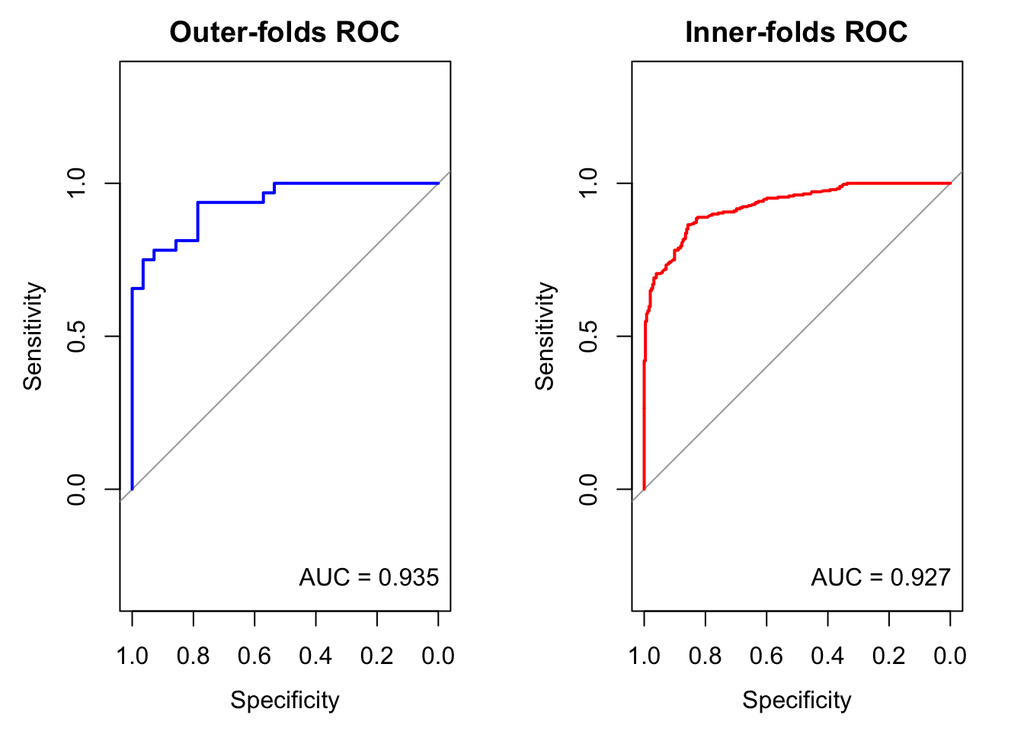

#### 2.5.3.3. Get final accuracy by fitting to the test data.

```r
preds <- predict(ncv,
                 newdata = test)
confusionMatrix(preds, test$Treatment)
```

```
## Confusion Matrix and Statistics
##
##           Reference
## Prediction Control Cold
##    Control       3    1
##    Cold          4    6
##
##                Accuracy : 0.6429
##                  95% CI : (0.3514, 0.8724)
##     No Information Rate : 0.5
##     P-Value [Acc > NIR] : 0.2120
##
##                   Kappa : 0.2857
##
##  Mcnemar's Test P-Value : 0.3711
##
##             Sensitivity : 0.4286
##             Specificity : 0.8571
##          Pos Pred Value : 0.7500
##          Neg Pred Value : 0.6000
##              Prevalence : 0.5000
##          Detection Rate : 0.2143
##    Detection Prevalence : 0.2857
##       Balanced Accuracy : 0.6429
##
##        'Positive' Class : Control
##
```

**Hint**: Make sure to mention why/when ROC curves can be misleading.

> There are multiple reasons ROC curves can be misleading. One is when there is a class imbalance. I checked this, and since the prevalence is 0.5, the dataset is balanced, so in this case, this is not the cause of the ROC curve being misleading.

> This shows that although the ROC and AUC are high, they may be misleading for our model, especially based on the results seen in the confusion matrix.

#### **Question 21**: Using help from generative AI or search engines, figure out how to assess the **stability** of the model across the nested folds. What conclusions can you draw? Write a 1-2 sentence conclusion for your stakeholders about whether or not you think the random forest is tunable and what you’d recommend next.

> There are various ways we can assess the stability of the model across the nested folds. Earlier, in Question 18, we checked the model stability across the folds. This code output the accuracy and kappa values for each of the 10 folds. One of the biggest takeaways from this code was that all 10 folds had identical accuracy and kappa values of 1. These are unlikely results that should be used with caution.

> Due to this, I do not think the Random Forest model is tunable. Although it did show some minor improvements, it was clear that our performance metrics were unlikely to improve. Since we have a big p little n problem, I would recommend trying a regularization model next. This may lead to better results through the use of penalties.

#### 2.5.3.4. Grab the important features.

Even if you decided that model performance is still poor and that you’d not recommend continuing with the RF, let’s practice grabbing the important features so you have code to do it.

Table 7. Important Features from the Nested CV Grid Search on Random Forest

|  | MeanDecreaseGini |
| --- | --- |
| LOC100747629 | 5.831230 |
| LOC105680838 | 3.803561 |
| LOC100742534 | 3.332846 |
| LOC100748198 | 3.153112 |
| LOC100749677 | 2.951891 |
| LOC100745262 | 2.862617 |
| LOC100740663 | 2.818878 |
| LOC100744324 | 2.798653 |
| LOC100746245 | 2.796210 |
| LOC100747964 | 2.656671 |

#### 2.5.3.5. Compare our gene results to the ones out of `DESeq2`.

Remember, the ultimate goal was to see which ML method was getting us close to results from `DESeq2`, the respected, conventional method.

Let’s filter the nested CV random forest importance:

Now let’s compare that to what we got out of `DESeq2`.

**Note** that I am setting a log-fold change filter to 1. In other words… any gene! Am I going to get any credible results?

Table 8. Overlapping Features identified from DESeq and Nested CV Random Forest

| baseMean | log2FoldChange | lfcSE | stat | pvalue | padj | geneID | MeanDecreaseGini |
| --- | --- | --- | --- | --- | --- | --- | --- |
| 306.648 | 1.057839 | 0.6978313 | 1.515895 | 0.1295459 | 0.9999865 | LOC100745464 | 1.0005 |

**IMPORTANT!** I have had this list reshuffle on me. I believe the issue is with the `rf_filter()` function we’re using, and is something to consider for reproducibility!

#### 2.5.3.6. Find out what our top gene from nested CV random forest does.

Although the gene list has shuffled a bit from run to run, I did want to give you an example of one gene that I keep seeing come up again and again and *one way* we might try to explore what these genes are and what they do. Because, at the end of the day, having a list of genes is rather dissatisfying if we want to know the underlying biology and mechanism of chill coma.

A second gene that came up frequently for me was **LOC100748162**, which is also a gene from *Bombus impatiens* and [encodes pancreatic lipase-related protein 2](https://www.ncbi.nlm.nih.gov/gene/?term=LOC100748162), another metabolism gene. So, it may suggest one of the physiological effects that happens to *B. impatiens* when it goes into chill-coma is an alteration in metabolism, which makes sense.

#### **Question 22**: Do you think we should we have any confidence in these results? Why or why not? Think about this from the perspective of what you would tell/advise your stakeholder.

> Source: https://www.ncbi.nlm.nih.gov/gene/?term=LOC100748162 Source: https://www.ncbi.nlm.nih.gov/gene/?term=LOC100749486 Source: https://pubmed.ncbi.nlm.nih.gov/20466006/

> Gene LOC100748162 is a gene from Bombus impatiens that encodes pancreatic lipase-related protein 2. This was one of the genes that Professor Geist also saw in her models. As she mentioned above, it is a metabolism gene and in the context of this dataset, it could indicate that an alteration in metabolism can happen when the Bombus impatiens go into a chill coma.

> Gene LOC100749486 is a gene from Bombus impatiens that encodes abaecin. According to the National Library of Medicine, abaecin is an antimicrobial peptide that is an important part of the immune system of Bombus impatiens. It is also involved in hemolymph coagulation, which has to do with blood clotting. This indicates that both the immunity and blood clotting of Bombus impatiens may be affected when they go into a chill coma. This is interesting and shows just how much impact chill comas have on Bombus impatiens.

# 3 Takeaways & Next Steps

## 3.1 Enter Phase 2 of this Project:

As we move forward with our benchmarking study, you have two choices. Choose your own adventure!

- **Path 1** - Potentially easier and more satisfying.

  Perform $k$-fold & nested CV Random Forest, as well as hyperparameter tuning, on a different VST from the 30-minute experiment only.

  If you decide to choose this adventure, you will use the VST data for the 30-min time point expression data only. You will also be given the `DESeq` results so you can use the `findOverlappingGenes()` function again to look at performance. Your task will be to take this vst, and work through all the same steps as in this first-half of the project. **Make sure to look at the important features at the end and comment on whether you have any confidence in your results!**
- **Path 2** - Potentially more challenging, and possibly dissatisfying.

  Ready to do go farther? Try performing $k$-fold & nested CV, as well as hyperparameter tuning, on SVM.

  If you choose this adventure, you will have the option to work through this same vst OR the 30-minute VST and your challenge is to apply SVM, including tuning the hyperparameters of **kernel**, **gamma**, and **cost**. Currently, we cannot get the important features out of nested cv SVM easily (alas - it needs another custom function!), so for this project you only need to engineer a best SVM model, discuss why you think it’s the best model, and what your next recommendations are.

# 4 Final Comments / Advice

- Make sure to use the template I provide on GitHub for the project, rather than adding on to this document. It will just get too long! **If you can’t upload the knitted file, just submit a note on Canvas that it wouldn’t knit and that yoour RMD is on on your Team GitHub.* I expect some folks may have difficulty knitting. Be patient, too. It might take a half-hour or longer.
- **Don’t forget!** Answer questions scattered throughout the Random Forest CV and Tuning Sections to ensure your understanding (you may copy these answers, without code, to your project document.)

**Files you need for the 30-min data will be found in the `data_30min` directory**:

1. `vst_30_min.Rdata` = the 30-min equivalent of the `vsData` object with the VST normalized read counts, formatted and ready to use as in this walk-through.
2. `vst_30_min.txt` = a text file version, which you likely do not need
3. `DESeq_on_30min_Data.Rmd` = an RMD file that was used to generate the 30-min data, plus some exploratory analysis. For the results see #4.
4. `DESeq_on_30_Data.html` = knitted file with some EDA and results to get you better acquainted to the data. Take a look! :)
5. `DESeqResults_30_min.Rdata` = the 30-min equivalent of the `DESeqResults` object that you can use with this walk-through.

**You will absolutely need to take a look at #4 to get you started. You will also want to use #1 and #5 for your analysis.**

# 5 Phase 2 of Project: Path 1

I have chosen to complete Path 1 for Phase 2 of the project: Perform $k$-fold & nested CV Random Forest, as well as hyperparameter tuning, on a different VST from the 30-minute experiment only.

If you decide to choose this adventure, you will use the VST data for the 30-min time point expression data only. You will also be given the `DESeq` results so you can use the `findOverlappingGenes()` function again to look at performance. Your task will be to take this vst, and work through all the same steps as in this first-half of the project. **Make sure to look at the important features at the end and comment on whether you have any confidence in your results!**

## 5.1 Load in the data:

```r
# Load in 30m data needed for Phase 2 of project
load("/Users/elizabethgreenan/Documents/DSE6330/Merrimack_DSE6630/Team_Directories/lambda/Module_Projects/Project_3/data_30min/vst_30_min.Rdata")

# Load in DESeq2 results
load("/Users/elizabethgreenan/Documents/DSE6330/Merrimack_DSE6630/Team_Directories/lambda/Module_Projects/Project_3/data_30min/DESeqResults_30_min.Rdata")
```

> NOTE: No variables were renmaed in Phase 2, as I chose to overwrite the variables from Phase 1.

## 5.2 Pre-processing and feature selection

Set `filterCutoff = 5` and partition data for random forest tuning.

```r
splits <- doSplits(vst = vsData,
                   algorithm = "rf",
                   splitRatio = 0.8,
                   filterCutoff = 5)
```

```
## [1] "After filtering, number of genes in the dataset are: 8553"
```

```r
train <- splits[[1]]
test <- splits[[2]]
```

> After filtering, there are 8,553 genes in the dataset. Phase 1 had 7,676 genes after filtering. This indicates that the 30 minute data retains more genes than the original dataset while using the same filterCutoff value and splitRatio. Additionally, although both datasets have the big p little n problem, this problem is much more pronounced in the 30 minute dataset. This makes sensem but can cause the results to vary since there are so few samples.

## 5.3 Apply $k$-fold Cross-Validation (CV) to Random Forest

### 5.3.1. Leverage the `trainControl()` and `train()` functions from the `caret` package.

Fit the same RF we fit last week for comparison:

```r
rfOOB <- randomForest::randomForest(
  Treatment ~ .,
  data = train)

pred.test.rf <- predict(rfOOB, test, type = "response")
confMat <- confusionMatrix(pred.test.rf, test$Treatment)
```

### 5.3.2. Employ a $k$-fold CV where $k = 10$.

Employ a $k$-fold CV where $k = 10$.

Set the control for $k = 10$ and then run the RF:

```r
# Set the CV arguments
kFoldCtrl <- trainControl(method = "cv",    ## for k-fold CV
                          number = 10)      ## k
```

And fit the Random Forest model:

```r
rfCV <- train(Treatment ~.,
               data = train,
               method = "ranger",
               trControl = kFoldCtrl)    ## added in the 10-fold CV
```

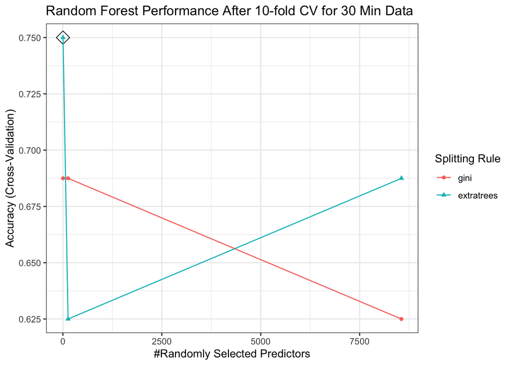

Figure 1. Visualize the 10-fold CV Performance for 30 Min Data

### 5.3.3. Extract best model.

You can also extract the best model as well to get the precise combination of hyperparameters.

Table 1. Hyperparameters of the best Random Forest Model using 10-fold CV for 30 Min Data

|  | mtry | splitrule | min.node.size |
| --- | --- | --- | --- |
| 2 | 2 | extratrees | 1 |

### 5.3.4. Assess for model stability.

Let’s look at the fold-specific results for our best model. This is essential to assess **stability** of the model.

Table 2. Fold-specific accuracy for the 10-fold CV Random Forest for 30 Min Data

| Accuracy | Kappa | Resample |
| --- | --- | --- |
| 0.5 | 0 | Fold2 |
| 0.0 | 0 | Fold3 |
| 1.0 | NA | Fold1 |
| 1.0 | 1 | Fold7 |
| 1.0 | 1 | Fold5 |
| 0.5 | 0 | Fold8 |
| 1.0 | 1 | Fold6 |
| 1.0 | 1 | Fold4 |

```r
# Create accuracy vector with only 9 values

accuracy <- c(0, 1, 1, 1, 0, 1, 1, 1, 0)

# Calculate average accuracy
average_accuracy <- mean(accuracy)
# Calculate minimum accuracy
minimum_accuracy <- min(accuracy)
# Calculate maximum accuracy
maximum_accuracy <- max(accuracy)

average_accuracy
```

```
## [1] 0.6666667
```

```r
minimum_accuracy
```

```
## [1] 0
```

```r
maximum_accuracy
```

```
## [1] 1
```

```r
# Check training and testing split to answer the question
nrow(train)
```

```
## [1] 14
```

```r
nrow(test)
```

```
## [1] 2
```

> The above code shows that the training set has 14 observations and the test set has 2 observations. This is a much smaller number of observations than the original dataset, further emphasizing the big p little n problem.

### 5.3.5. Fit the test data to the best tuned model from the 10-fold CV.

```r
rfCV <- train(Treatment ~.,
               data = train,
               method = "ranger",
               trControl = kFoldCtrl,
               tuneGrid = rfCV$bestTune)   ## Add in the results of the CV
                                           ## and auto tuning

pred.test.rf <- predict(rfCV, test, type = "raw")  ## type is now 'raw'
## Store the confusion matrix for later comparison
confMatCV <- confusionMatrix(pred.test.rf, test$Treatment)
```

### 5.3.6. Compare the two confusion matrices.

Lastly, let’s compare the results of what we just ran (stored in `confMatCV`) with what we the OOB performance from Demo_3 (stored in `confMat`).

Table 3. Comparing Accuracy - Random Forest for 30 Min Data

| Metric | Confusion Matrix 1 | Confusion Matrix 2 |
| --- | --- | --- |
| Accuracy | 0.5000000 | 0.5000000 |
| Kappa | 0.0000000 | 0.0000000 |
| AccuracyLower | 0.0125791 | 0.0125791 |
| AccuracyUpper | 0.9874209 | 0.9874209 |
| AccuracyNull | 0.5000000 | 0.5000000 |
| AccuracyPValue | 0.7500000 | 0.7500000 |
| McnemarPValue | 1.0000000 | 1.0000000 |

> Table 3 shows identical results between Confusion Matrix 1 (OOB) and Confusion Matrix 2 (10-Fold CV). This is likely due to the very small sample size in the 30 minute dataset. Therefore, the models are having a difficult time generalizing, due to such small variance in the number of samples. These results must be interpreted with caution.

## 5.4 Further Tuning: Searching

**NOTE**: When you strike out on your own, you may get a ‘bad seeds’ error. This is often because you need to increase the size of your sample space.

#### 5.4.1.1. Set the search grid.

```r
searchGrid <- expand.grid(
  mtry = floor(ncol(train) * c(.05, .15, .25, .35, .45)),
  splitrule = c("gini", "extratrees"),
  min.node.size = c(1, 3, 5, 10)
)
```

```r
# Calculate the number of different combinations we will search with this grid
5 * 2 * 4
```

```
## [1] 40
```

> Just like in Phase 1, we will search 40 different combinations with this grid.

#### 5.4.1.2. Run the RF, this time adding in the search grid.

Be patient. This may take a few minutes to run.

```r
rfTuned <- train(Treatment ~.,
               data = train,
               method = "ranger",
               trControl = kFoldCtrl,
               tuneGrid = searchGrid # Add in the search grid
)
```

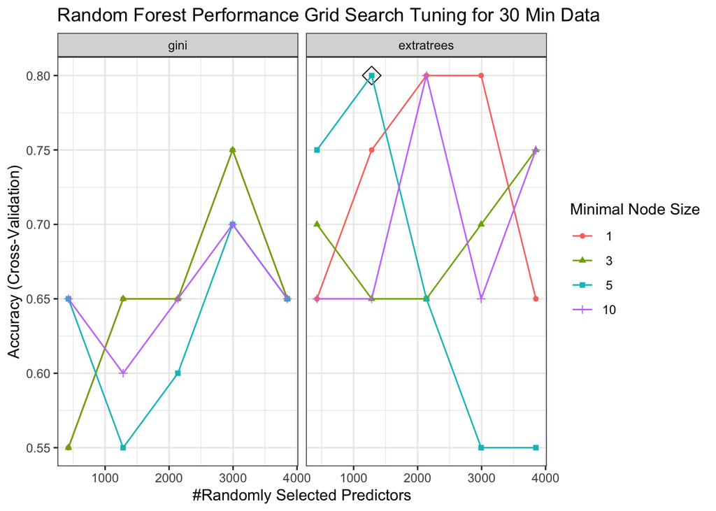

Figure 2. Visualize the Grid Search Performance for 30 Min Data

#### 5.4.1.3. Take a look at the hyperparameters of the best model.

```r
rfTuned$bestTune %>%
kable(
    format = "html",
    caption = "Table 3. Results of the Grid Search on Random Forest for 30 Min Data") %>%
    kable_styling(bootstrap_options = c("hover", full_width = F))
```

Table 3. Results of the Grid Search on Random Forest for 30 Min Data

|  | mtry | splitrule | min.node.size |
| --- | --- | --- | --- |
| 15 | 1282 | extratrees | 5 |

#### 5.4.1.4. Fit the best model’s hyperparameters to the test data.

```r
rfTuned <- train(Treatment ~.,
               data = train,
               method = "ranger",
               trControl = kFoldCtrl,
               tuneGrid = rfTuned$bestTune)   ## Use the best model
```

#### 5.4.1.5. Make the new predictions to assess accuracy.

```r
pred.test.rf <- predict(rfTuned, test, type = "raw")  ## type is now 'raw'
# Store the confusion matrix
confMatTuned <- confusionMatrix(pred.test.rf, test$Treatment)
```

#### 5.4.1.6. Compare the three confusion matrices.

```r
compareConfusion(confusionList = list(confMat, confMatCV, confMatTuned)) %>%
    kable(
    format = "html",
    caption = "Table 4. Comparing Accuracy - Random Forest for 30 Min Data") %>%
    kable_styling(bootstrap_options = c("hover", full_width = F))
```

Table 4. Comparing Accuracy - Random Forest for 30 Min Data

| Metric | Confusion Matrix 1 | Confusion Matrix 2 | Confusion Matrix 3 |
| --- | --- | --- | --- |
| Accuracy | 0.5000000 | 0.5000000 | 0.5000000 |
| Kappa | 0.0000000 | 0.0000000 | 0.0000000 |
| AccuracyLower | 0.0125791 | 0.0125791 | 0.0125791 |
| AccuracyUpper | 0.9874209 | 0.9874209 | 0.9874209 |
| AccuracyNull | 0.5000000 | 0.5000000 | 0.5000000 |
| AccuracyPValue | 0.7500000 | 0.7500000 | 0.7500000 |
| McnemarPValue | 1.0000000 | 1.0000000 | 1.0000000 |

> Once again, the results from Confusion Matrix 1 (OOB), Confusion Matrix 2 (10-Fold CV), and Confusion Matrix 3 (Grid Search) output identical metrics. These results are likely due to the big p little n problem. The accuracy for all three models is 0.5 and the kappa for all three models is 0. These results indicate that the models are not performing any better than random guessing.

### 5.4.2 Grid Search Using a Customized `caret` Method

#### 5.4.2.1. Write a customized `caret` method for random forest using the `ranger` method.

#### 5.4.2.2. Run the customized method.

**NOTE**: This takes about 12 min to run on 16gb of RAM. This is exactly why we are doing caching for this assignment. Otherwise, your report will take forever to re-knit.

```r
## Run the custom method setting the hyperparameters we want to use
customRF <- makeCustomMethod(paramList = c("mtry",
                                           "num.trees",
                                           "min.node.size",
                                           "splitrule"),
                             methodName = "ranger")

## Now expand the search grid
searchGrid <- expand.grid(.mtry = floor(ncol(train) * c(.05, .15, .25)),
                        .num.trees = c(50, 200),
                        .min.node.size = c(1, 5, 10, 20),
                        .splitrule = "gini"
                        )
## Now run the RF with the custom tuned hypers and the new search grid
customTuned <- train(y = train$Treatment, x = train,
                method = customRF,
                metric = "Accuracy",
                tuneGrid = searchGrid,
                trControl = kFoldCtrl)
```

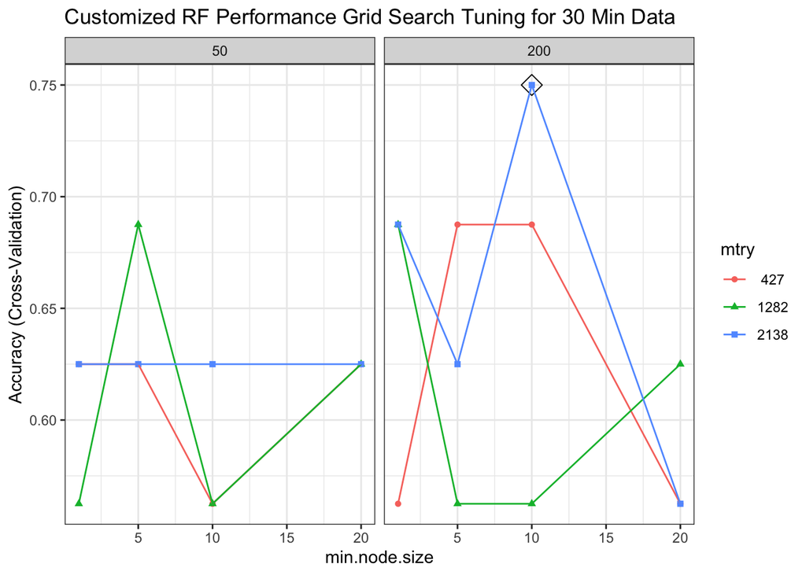

Figure 3. Visualize the Customized Grid Search Performance for 30 Min Data

#### 5.4.2.3. Take a look at the hyperparameters of the best model.

```r
customTuned$bestTune %>%
kable(
    format = "html",
    caption = "Table 5. Results of the Customized Grid Search on Random Forest for 30 Min Data") %>%
    kable_styling(bootstrap_options = c("hover", full_width = F))
```

Table 5. Results of the Customized Grid Search on Random Forest for 30 Min Data

|  | mtry | num.trees | min.node.size | splitrule |
| --- | --- | --- | --- | --- |
| 23 | 2138 | 200 | 10 | gini |

#### 5.4.2.4. Refit the best model’s hyperparameters to the test data set.

```r
newTuned <- train(Treatment ~.,
               data = train,
               method = customRF,
               trControl = kFoldCtrl,
               tuneGrid = customTuned$bestTune)
```

#### 5.4.2.5. Make the new predictions to assess accuracy.

```r
pred.test.rf <- predict(newTuned, test, type = "raw")
# Store the confusion matrix
confMatTuned2 <- confusionMatrix(pred.test.rf, test$Treatment)
```

#### 5.4.2.6. Compare the four confusion matrices.

Table 6. Comparing Accuracy - Random Forest for 30 Min Data

| Metric | Confusion Matrix 1 | Confusion Matrix 2 | Confusion Matrix 3 | Confusion Matrix 4 |
| --- | --- | --- | --- | --- |
| Accuracy | 0.5000000 | 0.5000000 | 0.5000000 | 0.5000000 |
| Kappa | 0.0000000 | 0.0000000 | 0.0000000 | 0.0000000 |
| AccuracyLower | 0.0125791 | 0.0125791 | 0.0125791 | 0.0125791 |
| AccuracyUpper | 0.9874209 | 0.9874209 | 0.9874209 | 0.9874209 |
| AccuracyNull | 0.5000000 | 0.5000000 | 0.5000000 | 0.5000000 |
| AccuracyPValue | 0.7500000 | 0.7500000 | 0.7500000 | 0.7500000 |
| McnemarPValue | 1.0000000 | 1.0000000 | 1.0000000 | 1.0000000 |

> The hyperparameter tuning with the number of trees and the new grid search (Confusion Matrix 4) had identical metrics to the OOB model (Confusion Matrix 1), the 10-Fold CV model (Confusion Matrix 2), and the original grid search model (Confusion Matrix 3). All four models have an accuracy of 0.50 (50%) and a kappa of 0, once again indicating that these models perform only as well as randomly guessing.

```r
# Check model stability across folds
customTuned$resample
```

```
##   Accuracy Kappa Resample
## 1      0.5     0    Fold4
## 2      1.0     1    Fold8
## 3      0.0     0    Fold2
## 4      1.0     1    Fold5
## 5      1.0     1    Fold3
## 6      1.0     1    Fold1
## 7      0.5     0    Fold6
## 8      1.0    NA    Fold7
```

> This does not provide any improvement in results. Therefore, it is not worth continuing down this path. We greatly condensed the amount of data we are using when we switched to the 30 minute dataset. Therefore, we are continuing to struggle with obtaining useful information from this model.

### 5.5.3 Running a Nested CV

#### 5.5.3.1. Set a search grid and train the model using the `nestedcv.train()` function.

Note that the setup looks a little reminiscent of our customized `caret` function. That’s because the authors of this package are doing something similar, although they have improved the computational speed. We could do that too - **if** we wanted to write a package. Otherwise, we can just let ours run and take a coffee/tea break. :)

**IMPORTANT!**: We are not able to use $m_{try}$ as large as we are used to because we’re doing inner- and outer-folds. We lowered $m_{try}$ here as a result. If you are doing this on different data and you get an error, that’s something to look into!

**Note**: This took 14 mins on 16gb RAM, depending on what else I was asking my computer to do at the same time.

```r
searchGrid <- expand.grid(.mtry = floor(ncol(train) * c(0.01, 0.05, 0.10)),
                        .min.node.size = c(1, 5, 10),
                        .splitrule = "gini"
                        )
ncv <- nestcv.train(y = train$Treatment, x = train,
                    method = 'ranger',
                    tuneGrid = searchGrid,
                    savePredictions = "final")
```

```
## 1 predictor(s) have var=0
```

```
## Fitting final model using CV on whole data
```

```
## Performing 10-fold outer CV, using 1 core
```

```
## Duration: 10.5726 mins
```

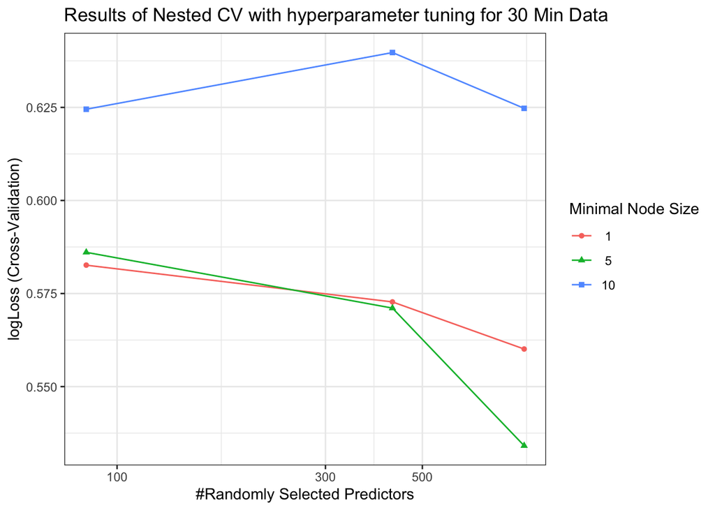

Figure 4. Visualize the Nested CV Performance on RF + Grid Search for 30 Min Data

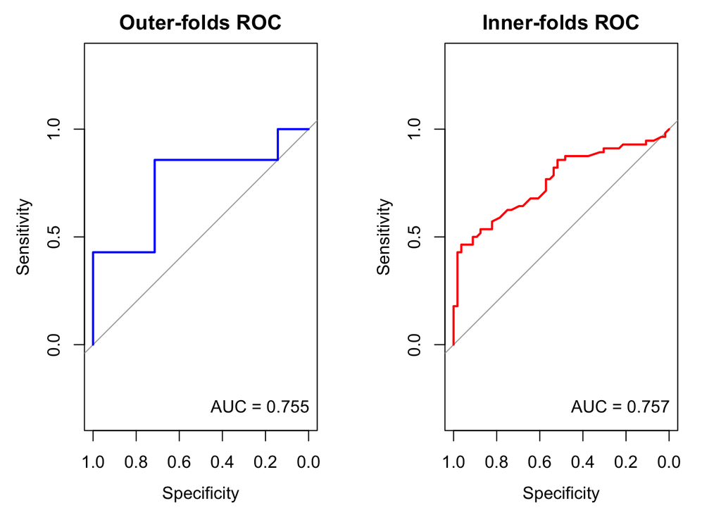

#### 5.5.3.3. Get final accuracy by fitting to the test data.

```r
preds <- predict(ncv,
                 newdata = test)
confusionMatrix(preds, test$Treatment)
```

```
## Confusion Matrix and Statistics
##
##           Reference
## Prediction Control Cold
##    Control       0    0
##    Cold          1    1
##
##                Accuracy : 0.5
##                  95% CI : (0.0126, 0.9874)
##     No Information Rate : 0.5
##     P-Value [Acc > NIR] : 0.75
##
##                   Kappa : 0
##
##  Mcnemar's Test P-Value : 1.00
##
##             Sensitivity : 0.0
##             Specificity : 1.0
##          Pos Pred Value : NaN
##          Neg Pred Value : 0.5
##              Prevalence : 0.5
##          Detection Rate : 0.0
##    Detection Prevalence : 0.0
##       Balanced Accuracy : 0.5
##
##        'Positive' Class : Control
##
```

> The model has a balanced accuracy of 0.5 (50%). This matches the no information rate, which is the baseline comparison. The big p little n issue continues to be an issue for many of our metrics, highlighting that while we have a large number of predictors, we have a small number of observations. This continues to impact our model results and makes it difficult to get useful information from them.

> The above code mentions that the positive class is Control. The confusion results are as follows: True Positives (TP): 0 False Positives (FP): 0 False Negatives (FN): 1 True Negatives (TN): 1 There is one False Negative and one True Negative value. This indicates that the model only correctly identifies one instance of the negative class (Cold). However, there are zero True Positives or False Positives. This shows that the model is not identifying the positive class (Control) at all.

#### 5.5.3.4. Grab the important features.

Even if you decided that model performance is still poor and that you’d not recommend continuing with the RF, let’s practice grabbing the important features so you have code to do it.

Table 7. Important Features from the Nested CV Grid Search on Random Forest for 30 Min Data

|  | MeanDecreaseGini |
| --- | --- |
| LOC117152307 | 2.431537 |
| LOC100748827 | 2.346662 |
| LOC100747290 | 1.995704 |
| LOC117151895 | 1.993650 |
| LOC100743463 | 1.970334 |
| LOC100747885 | 1.963374 |
| LOC100746666 | 1.813787 |
| LOC100745445 | 1.725845 |
| LOC100746100 | 1.724450 |
| LOC100742399 | 1.697303 |
| LOC100744502 | 1.697303 |

#### 5.5.3.5. Compare our gene results to the ones out of `DESeq2`.

Remember, the ultimate goal was to see which ML method was getting us close to results from `DESeq2`, the respected, conventional method.

Let’s filter the nested CV random forest importance:

Now let’s compare that to what we got out of `DESeq2`.

**Note** that I am setting a log-fold change filter to 1. In other words… any gene! Am I going to get any credible results?

Table 8. Overlapping Features identified from DESeq and Nested CV Random Forest for 30 Min Data

| baseMean | log2FoldChange | lfcSE | stat | pvalue | padj | geneID | MeanDecreaseGini |
| --- | --- | --- | --- | --- | --- | --- | --- |
| 6.390960 | 1.932657 | 0.5026503 | 3.844933 | 0.0001206 | 0.0398326 | LOC117152307 | 2.431537 |
| 3902.434875 | -4.084690 | 0.9200610 | -4.439587 | 0.0000090 | 0.0133650 | LOC100747885 | 1.963374 |
| 3.776269 | 1.630086 | 0.5848077 | 2.787388 | 0.0053135 | 0.1617796 | LOC100743721 | 1.409805 |
| 4.241027 | 1.115700 | 0.5004611 | 2.229345 | 0.0257910 | 0.3063579 | LOC117151836 | 1.342850 |
| 5.013643 | 1.454835 | 0.5732844 | 2.537719 | 0.0111578 | 0.2139452 | LOC100745235 | 1.000500 |
| 18.751964 | -1.526869 | 0.4053617 | -3.766684 | 0.0001654 | 0.0428296 | LOC100742047 | 1.000500 |
| 197.389060 | 1.393961 | 0.3424200 | 4.070910 | 0.0000468 | 0.0277763 | LOC117151185 | 1.000500 |
| 21.011759 | -2.803174 | 0.6862405 | -4.084827 | 0.0000441 | 0.0277763 | LOC117151235 | 1.000500 |
| 165.426575 | -3.578099 | 0.7964588 | -4.492509 | 0.0000070 | 0.0125250 | LOC100748162 | 1.000500 |
| 6.847508 | 1.071147 | 0.4096970 | 2.614487 | 0.0089362 | 0.1977737 | LOC100749318 | 1.000500 |
| 97.486059 | 1.518687 | 0.3526901 | 4.306010 | 0.0000166 | 0.0191387 | LOC112213068 | 1.000500 |
| 10.321264 | 1.045521 | 0.4722053 | 2.214124 | 0.0268203 | 0.3118604 | LOC100747341 | 1.000500 |
| 37.516296 | 1.052042 | 0.4235998 | 2.483576 | 0.0130071 | 0.2308078 | LOC112213654 | 1.000500 |

#### 5.5.3.6. Find out what our top gene from nested CV random forest does.

Source: https://www.ncbi.nlm.nih.gov/gene/?term=LOC100747885 Source: https://www.ncbi.nlm.nih.gov/gene/?term=LOC112213068 Source: https://pmc.ncbi.nlm.nih.gov/articles/PMC10701545/

> The most down regulated gene, LOC100747885, is a phospholipase A1 gene. The function of this gene is that it enables lipase activity.

#### 5.5.3.7. A note to the stakeholders.

> Additional analysis was performed, using the VST data for the 30 minute dataset. Some of the performance metrics had more realistic results, unlike the first part, where many of our models performed overly well. However, since the 30 minute data had such a small sample size, we were unable to gain truly insightful results from these models.

> The cause of this issue, as mentioned previously, is the big p little n issue. This is a common issue in gene data, so unfortunately, it is not overly surprising to see these results. We did see more overlapping genes in Phase 2 of the project, but any results from this study should be used with caution.

# References

Love, Michael I., Wolfgang Huber, and Simon Anders. 2014. “Moderated Estimation of Fold Change and Dispersion for RNA-Seq Data with DESeq2.” *Genome Biology* 15 (12): 550. https://doi.org/10.1186/s13059-014-0550-8.

R Core Team. 2019. *R: A Language and Environment for Statistical Computing*. Vienna, Austria: R Foundation for Statistical Computing. https://www.R-project.org.

Vabalas, Emma AND Poliakoff, Andrius AND Gowen. 2019. “Machine Learning Algorithm Validation with a Limited Sample Size.” *PLOS ONE* 14 (11): 1–20. https://doi.org/10.1371/journal.pone.0224365.

Verble, Kelton M., Ellen C. Keaveny, Sarthok Rasique Rahman, Matthew J. Jenny, Michael E. Dillon, and Jeffrey D. Lozier. 2024. “A Rapid Return to Normal: Temporal Gene Expression Patterns Following Cold Exposure in the Bumble Bee *Bombus Impatiens*.” *Journal of Experimental Biology* 227 (9): jeb247040. https://doi.org/10.1242/jeb.247040.